## Research Internship - Summer 2021

### Data analysis for OSHA “Occupational Safety and Health Administration”

## Question of Interest:

#### Which of the predictors “initial penalty fee”, “current penalty paid”, and “people exposed” explain the seriousness of “violation” in facilities?

## Approach:

#### Hypothesis test, multiple linear regression, data visualization

## Contents:

#### Part 1: Load Packages and Datasets

#### Part 2: About Variable

#### Part 3: Data Analysis

#### Part 4: Extended Data Analysis

#### Part 5: Data Visualization

#### Part 6: Reflection

## —————————————————————————————————

## Part One: Load packages and dataset

## —————————————————————————————————

## Part Two: About Variable

| VARIABLE NAME | DEFINTION | WHY IS THIS VARIABLE RELEVANT? WHAT DOES IT INDICATE? |
| --- | --- | --- |
| *nr_violations.1* | *Total number of reported violations from all inspections* | *This variable consist of the frequency of violation per facility and it serve as investigative measure of toxicity (either health or safety) in the facility* |
| *total_exposed.1* | *Total number of people reported to be exposed from all violations cited* | *Individuals who are exposed from the hazardous substances can indicate a better fit because it can help to determine how serious the violation was or not* |
| *iptotal.1* | *Penalty amount that a facility was initially charged per initial violation* | *First penalty amount in USD per each violation per facility can be a better fit as the price can be a proxy variable to indicate worth or seriousness of violation* |
| *cptotal.1* | *Total penalty amount that a facility paid for the entire violation* | *Total amount of penalty paid in USD for entire violation per facility can be a better fit as it can indicate accountability of the facility* |

## —————————————————————————————————

## Part Three: Data analysis

### About Data

```
## [1] "There are total 149 observations and below is table of 20 sample observations from the dataset:"
```

```
##       Violation Exposed InitialP CurrentP
##  [1,]         8       0     1860     1050
##  [2,]         0       0        0        0
##  [3,]         0       0        0        0
##  [4,]        35     685   127685    63295
##  [5,]        13    1136     6005     4570
##  [6,]         0       0        0        0
##  [7,]         0       0        0        0
##  [8,]         0       0        0        0
##  [9,]         0       0        0        0
## [10,]         7       3    17250    11060
## [11,]         0       0        0        0
## [12,]         0       0        0        0
## [13,]         3      46     1495      775
## [14,]         2      97      600      600
## [15,]         0       0        0        0
## [16,]         0       0        0        0
## [17,]         2      21     5375     5375
## [18,]         0       0        0        0
## [19,]         0       0        0        0
## [20,]         0       0        0        0
```

```
## [1] "Mathematically, the First-order regression equation is:"
```

$Y = \beta_0 + \beta_1 X_i1 + \beta_2 X_i2 + \beta_3 X_i3 + \epsilon_i$

$Y_i$ = is number of violations per facility $i$

$X_1$ = is number of people exposed at facility $i$

$X_2$ = is amount in USD of initial penalty amount of facility $i$

$X_3$ = is amount in USD of current penalty payment of facility $i$

### Approach using Hypothesis Test

$H_O: \beta_1=\beta_2=\beta_3=0$

$H_A$: at least one $\beta_j \neq 0$ (for $j=1,2,3$)

```
## Analysis of Variance Table
##
## Response: Y
##            Df Sum Sq Mean Sq F value    Pr(>F)
## X           3 5737.3  1912.5  30.646 2.098e-15 ***
## Residuals 145 9048.5    62.4
## ---
## Signif. codes:  0 '***' 0.001 '**' 0.01 '*' 0.05 '.' 0.1 ' ' 1
```

This is a sufficient evidence that F = 30.64 and P-Value is less than 0.001, and we reject the null hypothesis to conclude that at least one predictor is useful in the model.

```
## [1] "Predictors 'X2=Initial amount' and 'X3=Current penalty paid' explain 39 % of the variation in the response variable that cannot be explained by 'X1=People Exposed' variable. "
```

### Approach using Multiple Regression Analysis

### a. Graphical representation and interpretation:

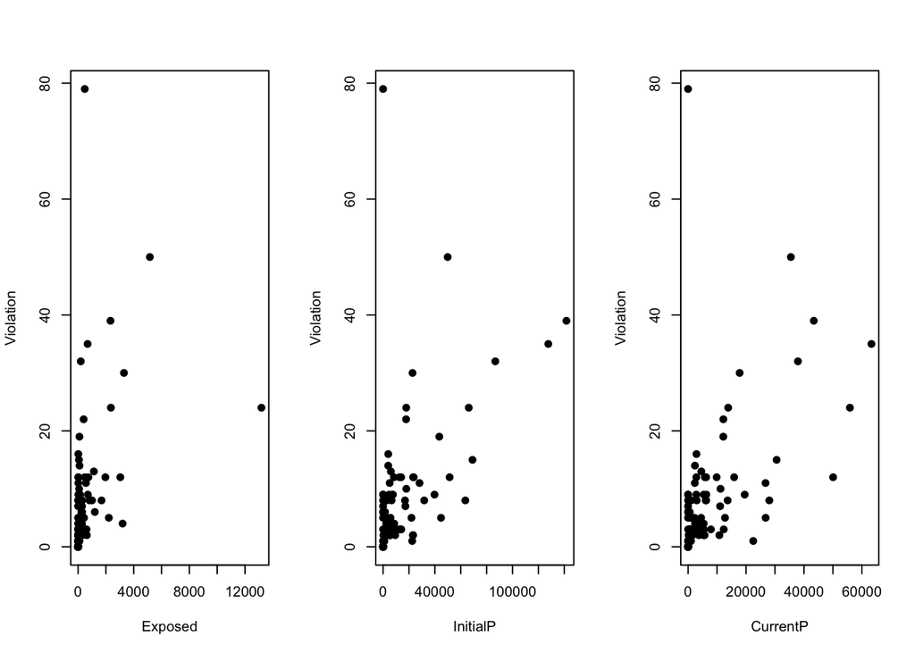

### b. Measure of central tendency

```
## [1] "People Exposed"
```

```
##    Min. 1st Qu.  Median    Mean 3rd Qu.    Max.
##     0.0     0.0     6.0   359.9   147.0 13181.0
```

Respondents’ exposed to toxicity range from 0-13181 peoples with a mean of 360 people exposed per facility. We have data distributed or skewed to the right.

```
## [1] "Initial Amount"
```

```
##    Min. 1st Qu.  Median    Mean 3rd Qu.    Max.
##       0       0     420    8827    6005  141680
```

The penalty amount charged to facilities range from 0 - 141680 USD, with a mean of 8827 USD per facility. We have data distributed or skewed to the right.

```
## [1] "Current Pay"
```

```
##    Min. 1st Qu.  Median    Mean 3rd Qu.    Max.
##       0       0     320    4933    4500   63295
```

The penalty amount charged to facilities range from 0 - 63295 USD, with a mean of 4933 USD per facility. We have data distributed or skewed to the right.

### c. Testing for multicollinearity diagnostic

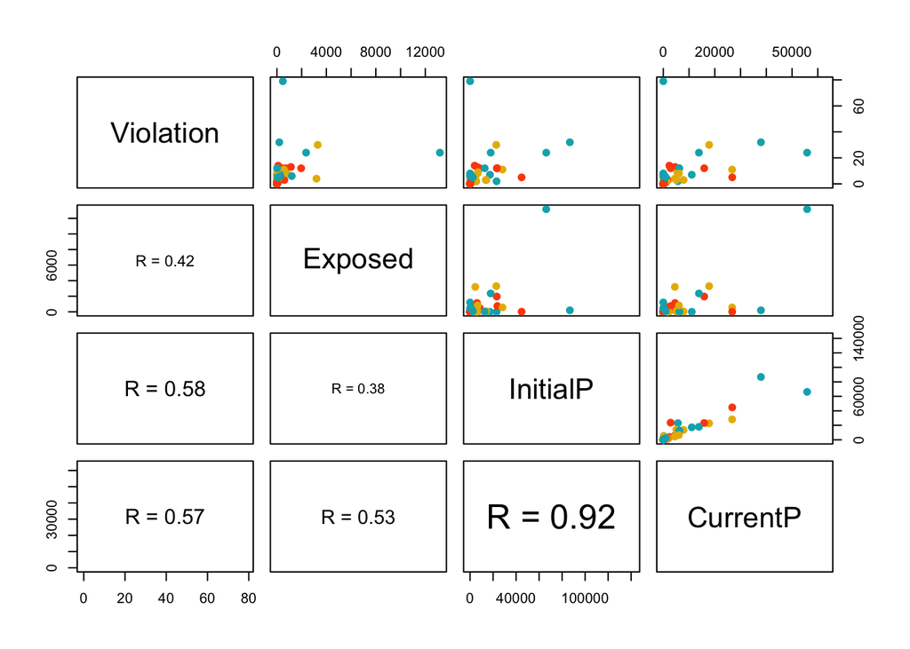

```
##      x1   x2   x3
## x1 1.00 0.38 0.53
## x2 0.38 1.00 0.92
## x3 0.53 0.92 1.00
```

There is a high correlation between the variable “CurrentPay” and “InitialAmount” where (r = 0.92)

```
##
## Call:
## lm(formula = x1 ~ x2 + x3)
##
## Residuals:
##     Min      1Q  Median      3Q     Max
## -4707.0  -102.8   -53.0   -17.4  8270.2
##
## Coefficients:
##             Estimate Std. Error t value Pr(>|t|)
## (Intercept) 53.00491   93.83046   0.565 0.573008
## x2          -0.04095    0.01033  -3.964 0.000115 ***
## x3           0.13548    0.02002   6.768 2.95e-10 ***
## ---
## Signif. codes:  0 '***' 0.001 '**' 0.01 '*' 0.05 '.' 0.1 ' ' 1
##
## Residual standard error: 1041 on 146 degrees of freedom
## Multiple R-squared:  0.3486, Adjusted R-squared:  0.3396
## F-statistic: 39.06 on 2 and 146 DF,  p-value: 2.586e-14
```

```
## Tolerance and Variance Inflation Factor
## ---------------------------------------
##   Variables Tolerance      VIF
## 1        x2 0.1567529 6.379467
## 2        x3 0.1567529 6.379467
##
##
## Eigenvalue and Condition Index
## ------------------------------
##   Eigenvalue Condition Index   intercept         x2         x3
## 1 2.20173938        1.000000 0.068984719 0.02443296 0.02421425
## 2 0.72989579        1.736811 0.923373122 0.01882749 0.01438694
## 3 0.06836484        5.675009 0.007642159 0.95673955 0.96139881
```

Conclusion is after reviewing two test of multicollinearity, the correlation matrix suggests there is collinearity between InitialAmount and CurrentPay. While, VIF and tolerance statistic suggest there is no collinearity. Therefore, we understand there is no multicollinearity in our data except the suggested collinearity between the two variables. Thus, we might continue with both of them in the model since we require them in our analysis.

### d. Model building

```
##
## Call:
## lm(formula = Y ~ X)
##
## Residuals:
##     Min      1Q  Median      3Q     Max
## -18.538  -2.619  -1.855   0.423  75.467
##
## Coefficients: (1 not defined because of singularities)
##               Estimate Std. Error t value Pr(>|t|)
## (Intercept)  2.619e+00  7.127e-01   3.675 0.000334 ***
## X                   NA         NA      NA       NA
## XExposed     1.905e-03  6.279e-04   3.033 0.002865 **
## XInitialP    2.471e-04  8.248e-05   2.996 0.003216 **
## XCurrentP   -2.771e-05  1.741e-04  -0.159 0.873752
## ---
## Signif. codes:  0 '***' 0.001 '**' 0.01 '*' 0.05 '.' 0.1 ' ' 1
##
## Residual standard error: 7.9 on 145 degrees of freedom
## Multiple R-squared:  0.388,  Adjusted R-squared:  0.3754
## F-statistic: 30.65 on 3 and 145 DF,  p-value: 2.098e-15
```

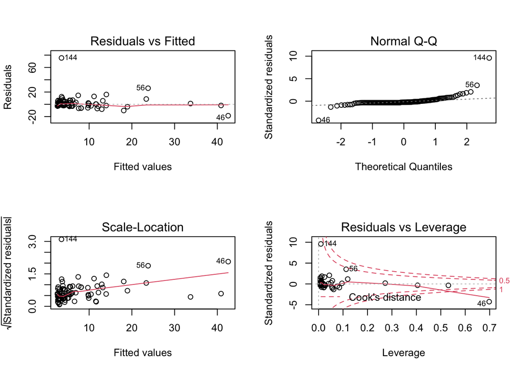

### 1. Check and Validate Assumption

```
##
## Call:
## lm(formula = log(Y + 1) ~ X)
##
## Residuals:
##     Min      1Q  Median      3Q     Max
## -2.0092 -0.8529 -0.1665  0.6614  3.4557
##
## Coefficients: (1 not defined because of singularities)
##              Estimate Std. Error t value Pr(>|t|)
## (Intercept) 8.529e-01  7.877e-02  10.828   <2e-16 ***
## X                  NA         NA      NA       NA
## XExposed    1.528e-04  6.940e-05   2.202   0.0292 *
## XInitialP   1.647e-05  9.116e-06   1.807   0.0728 .
## XCurrentP   2.273e-05  1.924e-05   1.182   0.2393
## ---
## Signif. codes:  0 '***' 0.001 '**' 0.01 '*' 0.05 '.' 0.1 ' ' 1
##
## Residual standard error: 0.8731 on 145 degrees of freedom
## Multiple R-squared:  0.3887, Adjusted R-squared:  0.3761
## F-statistic: 30.73 on 3 and 145 DF,  p-value: 1.937e-15
```

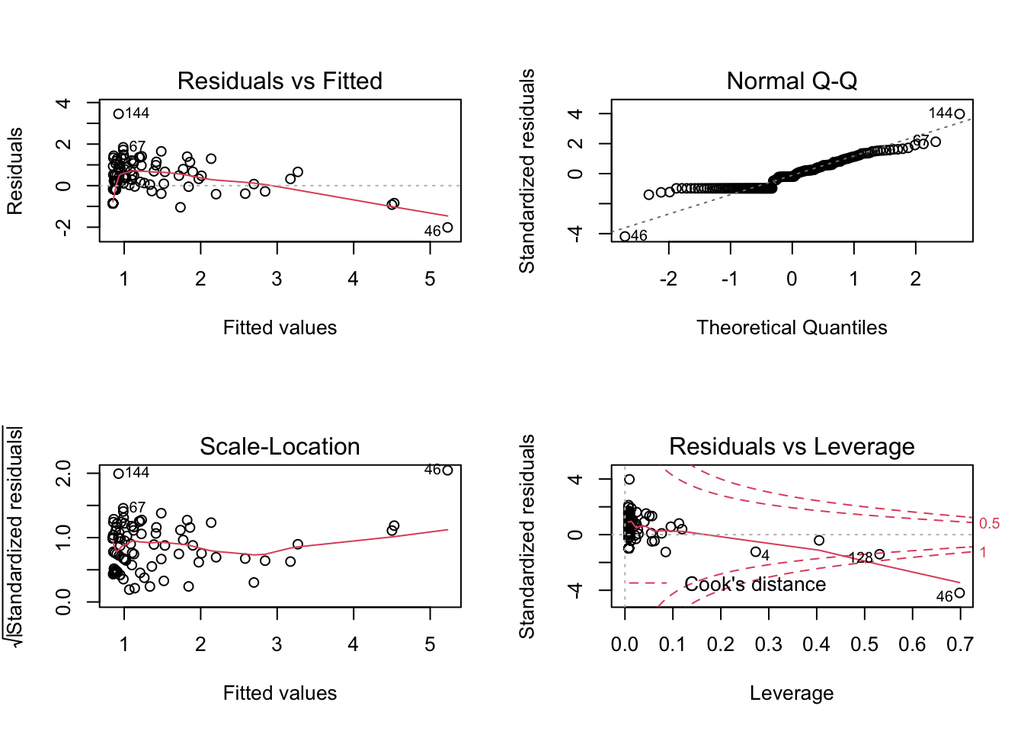

Transforming the dataset is not helping to normalize it, therefore I will continue the analysis without transforming it.

### 2. Data splitting

```
## [1] "There are 75 training and 74 validating/testing observations."
```

### 3. First-order model selection using best subsets criteria

### a. adjusted r squared

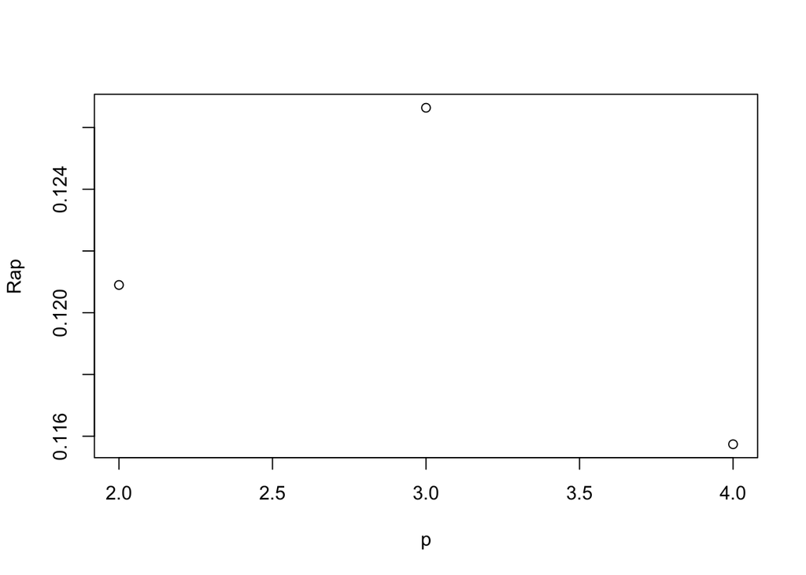

```
## [1] 2
```

```
## (Intercept)     Exposed    InitialP    CurrentP
##        TRUE        TRUE        TRUE       FALSE
```

### b. Cp

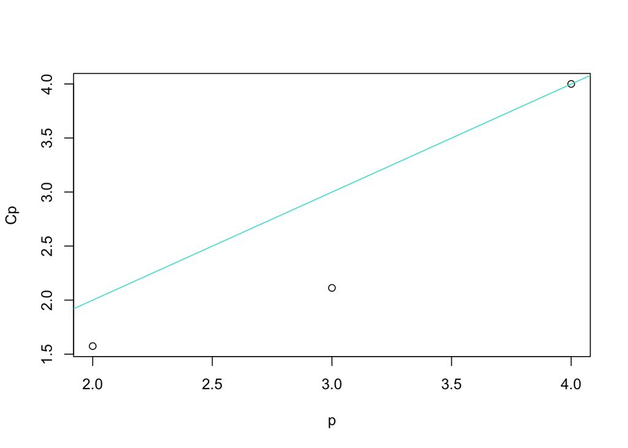

```
## 2
## 2
```

```
## (Intercept)     Exposed    InitialP    CurrentP
##        TRUE        TRUE        TRUE       FALSE
```

```
## [1] 1
```

```
## (Intercept)     Exposed    InitialP    CurrentP
##        TRUE       FALSE        TRUE       FALSE
```

The model with the lowest Cp−p has index 2, this includes all the predictor variables except Current penalty. The model with the lowest Cp has index 1, this includes all the predictor variables except Exposed and Current penalty.

### c. AIC

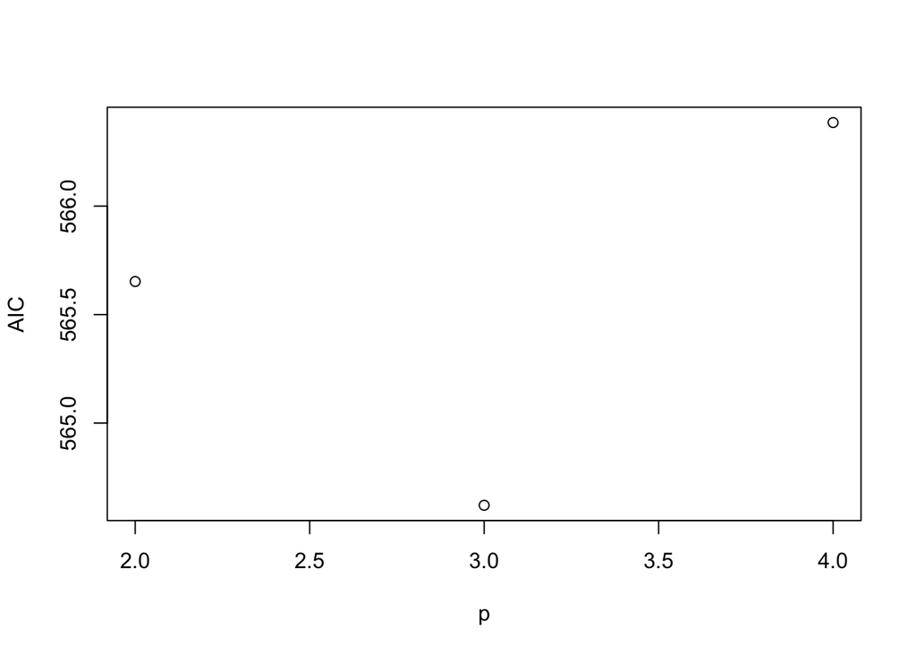

```
## 2
## 2
```

```
## (Intercept)     Exposed    InitialP    CurrentP
##        TRUE        TRUE        TRUE       FALSE
```

### d. BIC

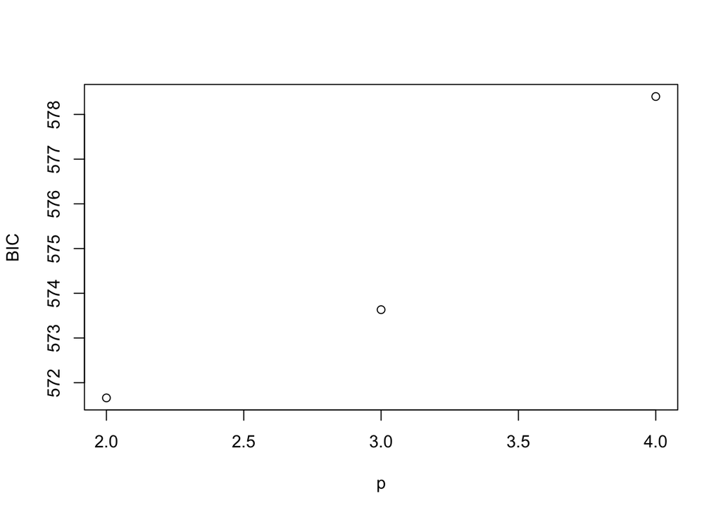

```
## 1
## 1
```

```
## (Intercept)     Exposed    InitialP    CurrentP
##        TRUE       FALSE        TRUE       FALSE
```

The model with the lowest BIC has index 1, this includes all the predictor variables except Exposed and Current Penalty. We expect BIC to choose a model with less predictor variables than AIC because it has a larger penalty on adding predictor variables for models with many predictor variables.

### e. PRESS

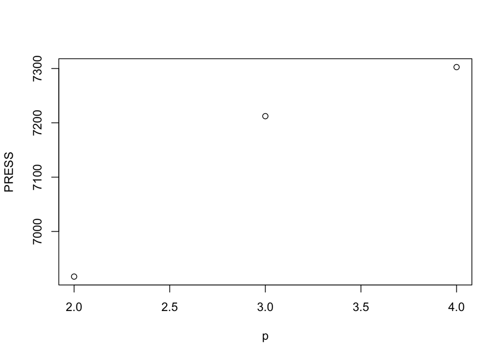

```
## [1] 1
```

```
## (Intercept)     Exposed    InitialP    CurrentP
##        TRUE       FALSE        TRUE       FALSE
```

The model with the lowest PRESS has index 1, this includes all the predictor variables except exposed and current penalty.

### b. 4. Model Diagnostic

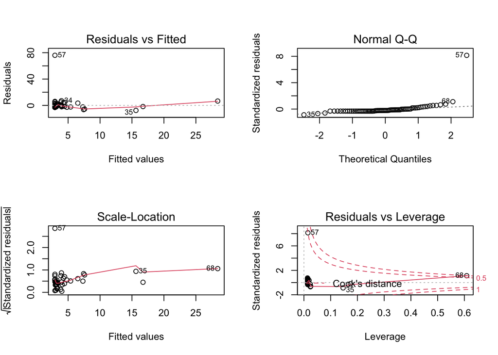

```
##
## Call:
## lm(formula = Y ~ ., data = data.frame(Xs[, temp]))
##
## Residuals:
##    Min     1Q Median     3Q    Max
## -7.621 -2.943 -1.989 -0.052 76.057
##
## Coefficients:
##              Estimate Std. Error t value Pr(>|t|)
## (Intercept) 2.943e+00  1.144e+00   2.572  0.01215 *
## Xs...temp.  1.995e-04  5.967e-05   3.343  0.00131 **
## ---
## Signif. codes:  0 '***' 0.001 '**' 0.01 '*' 0.05 '.' 0.1 ' ' 1
##
## Residual standard error: 9.407 on 73 degrees of freedom
## Multiple R-squared:  0.1328, Adjusted R-squared:  0.1209
## F-statistic: 11.18 on 1 and 73 DF,  p-value: 0.001309
```

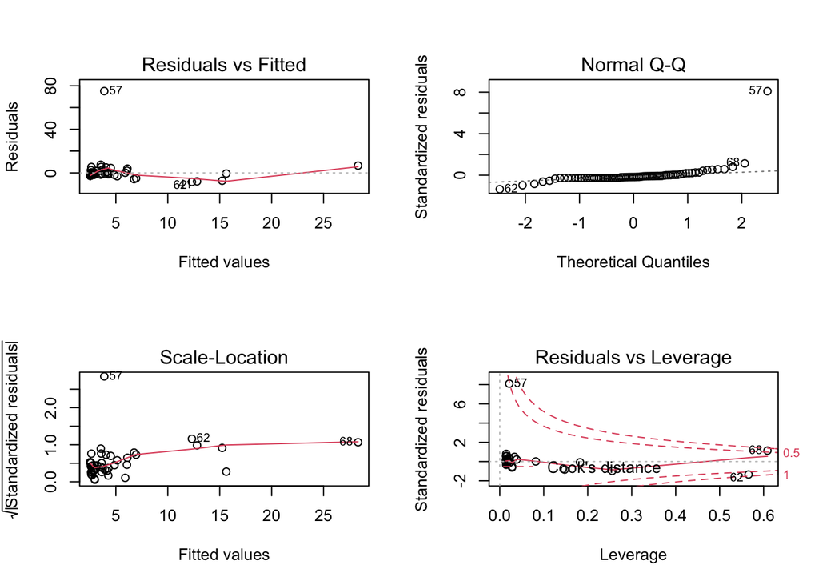

```
##
## Call:
## lm(formula = Y ~ ., data = data.frame(Xs[, temp]))
##
## Residuals:
##    Min     1Q Median     3Q    Max
## -8.317 -2.542 -1.619  0.075 75.118
##
## Coefficients:
##              Estimate Std. Error t value Pr(>|t|)
## (Intercept) 2.542e+00  1.187e+00   2.140  0.03571 *
## Exposed     2.792e-03  2.295e-03   1.216  0.22780
## InitialP    1.869e-04  6.036e-05   3.097  0.00279 **
## ---
## Signif. codes:  0 '***' 0.001 '**' 0.01 '*' 0.05 '.' 0.1 ' ' 1
##
## Residual standard error: 9.377 on 72 degrees of freedom
## Multiple R-squared:  0.1502, Adjusted R-squared:  0.1266
## F-statistic: 6.365 on 2 and 72 DF,  p-value: 0.002849
```

### b. 5. First-order with Two-way interaction model selection using stepwise algorithm

```
## Start:  AIC=349.88
## Y ~ 1
##
##            Df Sum of Sq    RSS    AIC
## + InitialP  1    989.12 6460.3 344.20
## + CurrentP  1    935.09 6514.3 344.83
## <none>                  7449.4 349.88
## + Exposed   1    275.90 7173.5 352.06
##
## Step:  AIC=344.2
## Y ~ InitialP
##
##            Df Sum of Sq    RSS    AIC
## <none>                  6460.3 344.20
## + Exposed   1    130.09 6330.2 347.68
## + CurrentP  1      1.72 6458.5 349.19
## - InitialP  1    989.12 7449.4 349.88
```

```
##
## Call:
## lm(formula = Y ~ InitialP, data = data.frame(Xs))
##
## Coefficients:
## (Intercept)     InitialP
##   2.9430410    0.0001995
```

There are 2^(3 + 3 choose 2) possible regression models. Again, the model selection chose the variable initial payment only! Thus, we conclude that the optimal model to predict seriousness of violation is the model that have initial payment as a predictor variable.

## —————————————————————————————————

## Part Four: Extended Data Analysis

```
## [1] 140   4
```

```
##       Violation Exposed InitialP CurrentP
##  [1,]         8       0     1860     1050
##  [2,]         0       0        0        0
##  [3,]         0       0        0        0
##  [4,]        35     685   127685    63295
##  [5,]        13    1136     6005     4570
##  [6,]         0       0        0        0
##  [7,]         0       0        0        0
##  [8,]         0       0        0        0
##  [9,]         0       0        0        0
## [10,]         7       3    17250    11060
## [11,]         0       0        0        0
## [12,]         0       0        0        0
## [13,]         3      46     1495      775
## [14,]         2      97      600      600
## [15,]         0       0        0        0
## [16,]         0       0        0        0
## [17,]         2      21     5375     5375
## [18,]         0       0        0        0
## [19,]         0       0        0        0
## [20,]         0       0        0        0
```

```
## Analysis of Variance Table
##
## Response: Y
##            Df Sum Sq Mean Sq F value    Pr(>F)
## X           3 6140.6  2046.9  89.006 < 2.2e-16 ***
## Residuals 136 3127.6    23.0
## ---
## Signif. codes:  0 '***' 0.001 '**' 0.01 '*' 0.05 '.' 0.1 ' ' 1
```

```
## [1] "Predictors 'X2=Initial amount' and 'X3=Current penalty paid' explain 66 % of the variation in the response variable that cannot be explained by 'X1=People Exposed' variable. "
```

### d. Model building

```
##
## Call:
## lm(formula = Y ~ X)
##
## Residuals:
##      Min       1Q   Median       3Q      Max
## -17.2561  -1.7277  -1.1683   0.4343  26.5909
##
## Coefficients: (1 not defined because of singularities)
##              Estimate Std. Error t value Pr(>|t|)
## (Intercept) 1.728e+00  4.490e-01   3.848 0.000183 ***
## X                  NA         NA      NA       NA
## XExposed    1.646e-03  3.837e-04   4.290 3.36e-05 ***
## XInitialP   2.371e-04  5.010e-05   4.732 5.51e-06 ***
## XCurrentP   3.822e-05  1.061e-04   0.360 0.719127
## ---
## Signif. codes:  0 '***' 0.001 '**' 0.01 '*' 0.05 '.' 0.1 ' ' 1
##
## Residual standard error: 4.796 on 136 degrees of freedom
## Multiple R-squared:  0.6625, Adjusted R-squared:  0.6551
## F-statistic: 89.01 on 3 and 136 DF,  p-value: < 2.2e-16
```

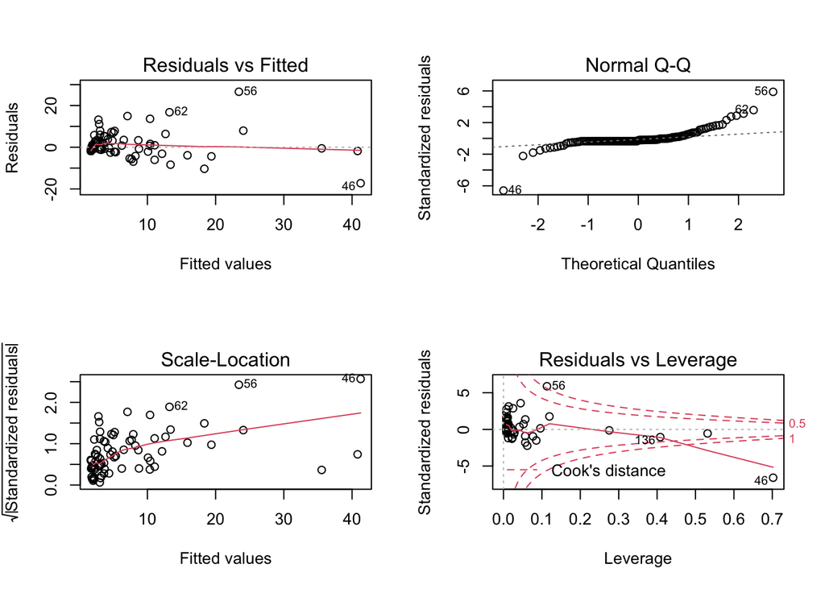

### 2. Data splitting

```
## [1] "There are 70 training and 70 validating/testing observations."
```

### 3. First-order model selection using best subsets criteria

### a. adjusted r squared

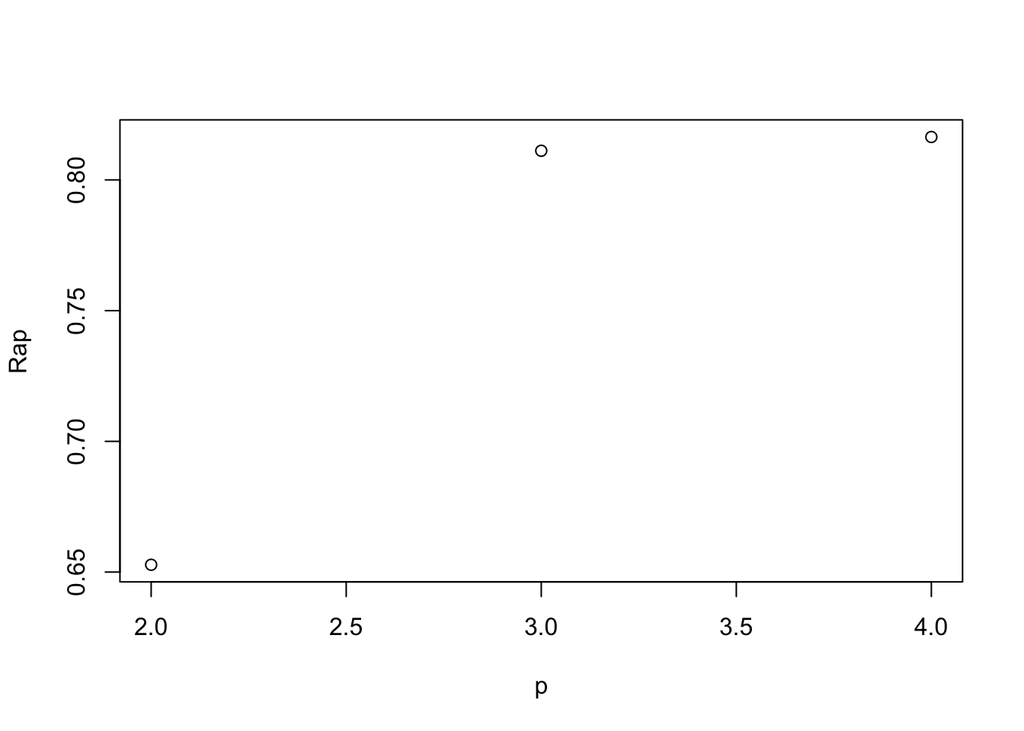

```
## [1] 3
```

```
## (Intercept)     Exposed    InitialP    CurrentP
##        TRUE        TRUE        TRUE        TRUE
```

### b. Cp

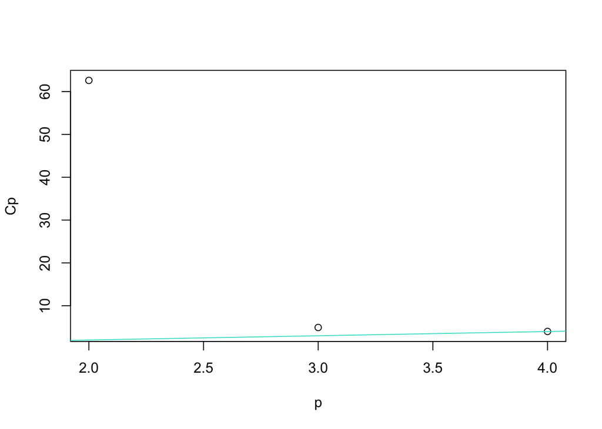

```
## 3
## 3
```

```
## (Intercept)     Exposed    InitialP    CurrentP
##        TRUE        TRUE        TRUE        TRUE
```

```
## [1] 3
```

```
## (Intercept)     Exposed    InitialP    CurrentP
##        TRUE        TRUE        TRUE        TRUE
```

### c. AIC

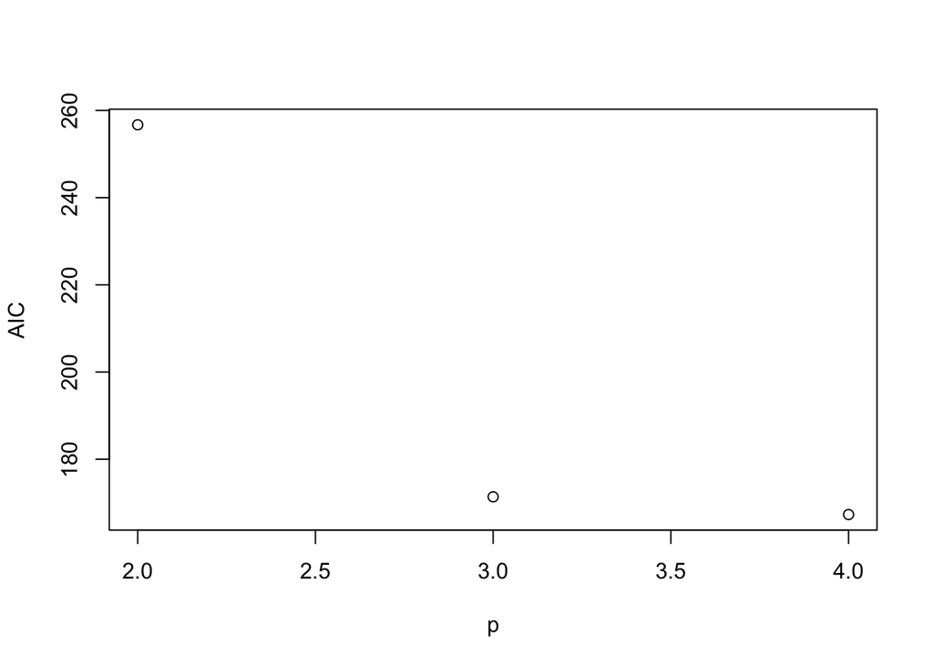

```
## 3
## 3
```

```
## (Intercept)     Exposed    InitialP    CurrentP
##        TRUE        TRUE        TRUE        TRUE
```

### d. BIC

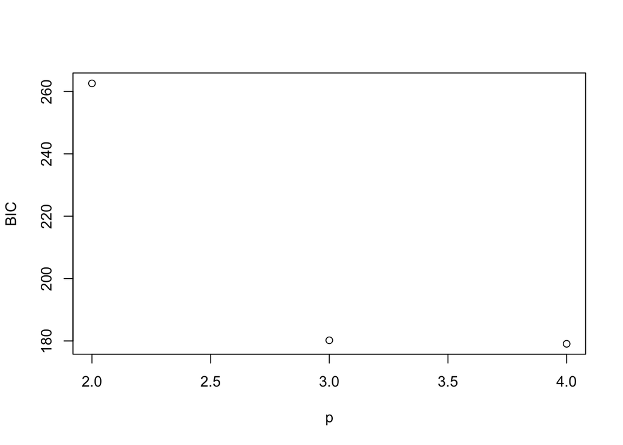

```
## 3
## 3
```

```
## (Intercept)     Exposed    InitialP    CurrentP
##        TRUE        TRUE        TRUE        TRUE
```

### e. PRESS

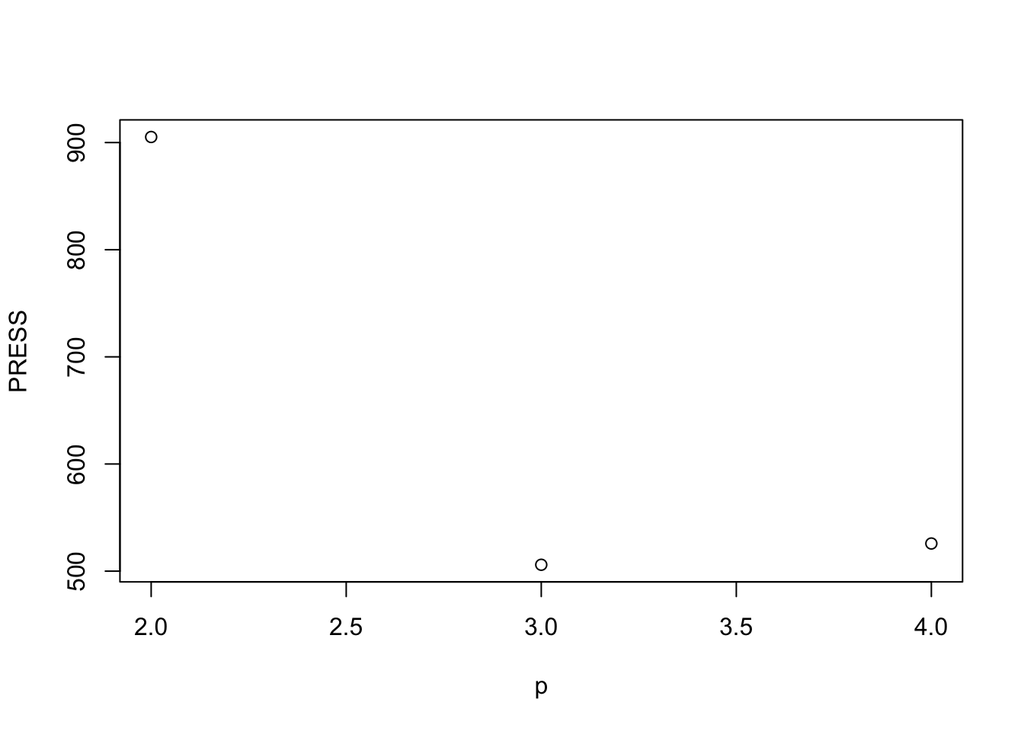

```
## [1] 2
```

```
## (Intercept)     Exposed    InitialP    CurrentP
##        TRUE        TRUE        TRUE       FALSE
```

## —————————————————————————————————

## —————————————————————————————————

## Part Five: Data Visualization

## —————————————————————————————————

```
## [1] "Variable: Owner Type"
```

```
##
##   A   B   C   D
##  18 123 524 132
```

*There are THREE types of Violation*

```
## [1] "Variable: Violation Type"
```

```
##
##   O   R   S
## 595  13 189
```

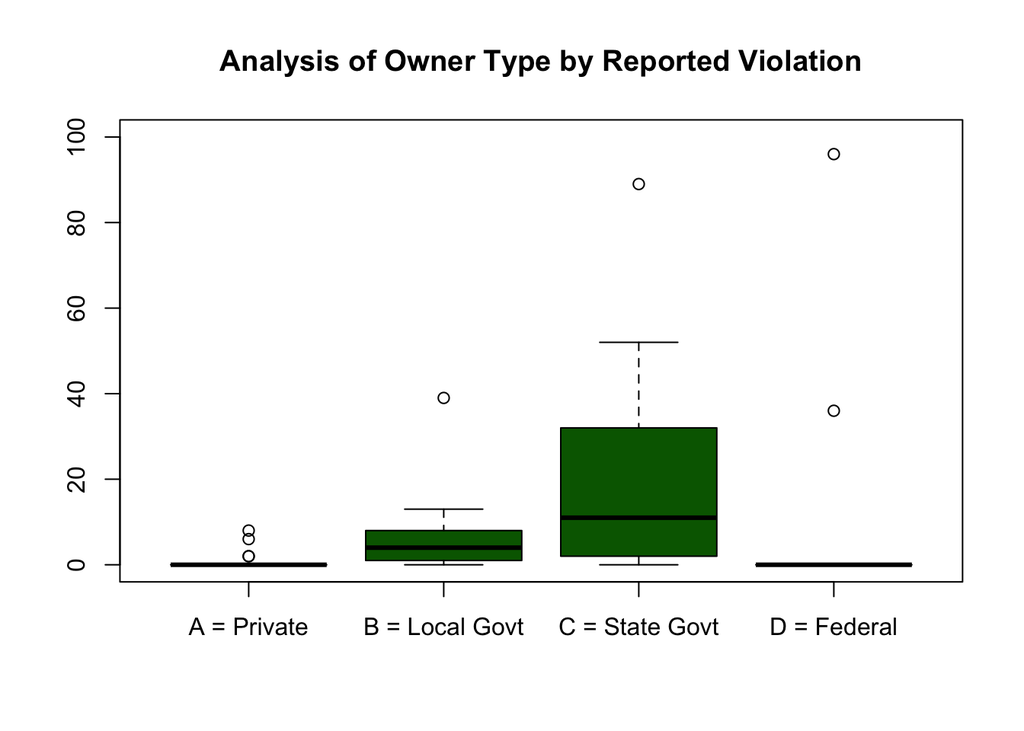

*We understand from the plot that state government have the highest reported violation whereas private facilities have the lowest reported violation compared to the other owners. We do not know if private facilities were very cautious from violation to prevent higher violation fees or to protect their license from cancellation. They have the lowest violation from the other type of facilities.*

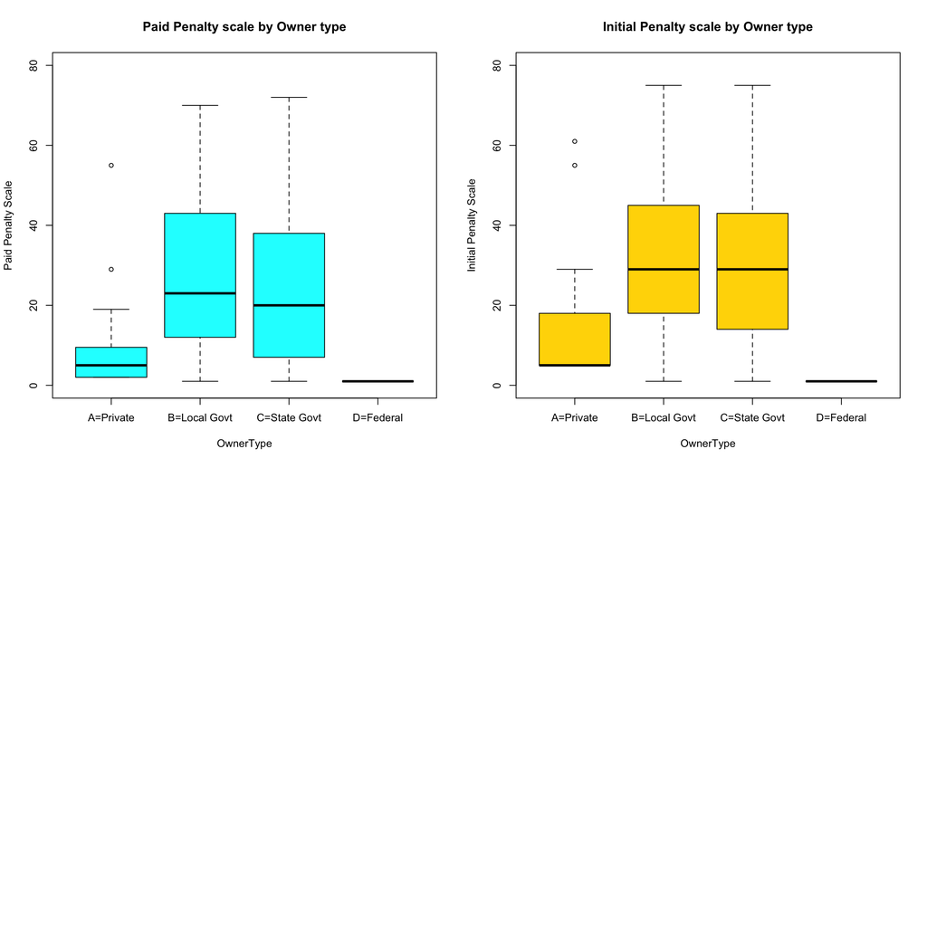

*We observe some differences between “Initial penalty” and “Paid penalty” on the whiskers for Private, Local and State government facility. This indicates some facilities were either paying more than charged or maybe paying less than the amount penalized.*